# Data Science Consulting: Midterm Team Project – Part 1

Clara Dragut, Yuwen Wang, Ziyao Wang

Nov 2025

```r
n.values <- c(500, 1000, 2000)
iterations <- 3
pixel_cols <- paste0("pixel", 1:49)
px_cols    <- pixel_cols
N_train_raw <- NA_integer_
```

```r
knn2 <- function(train_raw, test_raw, cl, k) {
  class::knn(train=train_raw, test=test_raw, cl=cl, k=k)
}

mk_res <- function(model_name, A,B,C,Points,time_sec) {
  list(Model=model_name, A=A, B=B, C=C, Points=Points, time_sec=time_sec)
}

summarize_results_df <- function(df, model_name, choose = c("best","mean")) {
  if (is.null(df) || nrow(df) == 0) return(NULL)
  choose <- match.arg(choose)


  if (!"time_sec" %in% names(df) && "runtime" %in% names(df)) {
    df$time_sec <- df$runtime
  }

  if (choose == "best") {
    i <- which.min(df$Points)
    row <- df[i, ]
    data.table::data.table(
      Model      = model_name,
      Summary    = "best",
      SampleSize = if ("SampleSize" %in% names(row)) row$SampleSize else NA_integer_,
      Iter       = if ("Iter" %in% names(row)) row$Iter else NA_integer_,
      Data       = if (all(c("SampleSize","Iter") %in% names(row)))
                     sprintf("dat_%s_%s", row$SampleSize, row$Iter) else NA_character_,
      A          = row$A,
      B          = row$B,
      C          = row$C,
      Points     = row$Points,
      time_sec   = row$time_sec
    )
  } else {
    data.table::data.table(
      Model      = model_name,
      Summary    = "mean",
      SampleSize = NA_integer_,
      Iter       = NA_integer_,
      Data       = NA_character_,
      A          = mean(df$A, na.rm = TRUE),
      B          = mean(df$B, na.rm = TRUE),
      C          = mean(df$C, na.rm = TRUE),
      Points     = mean(df$Points, na.rm = TRUE),
      time_sec   = mean(df$time_sec, na.rm = TRUE)
    )
  }
}
```

```r
train_path <- here::here("data", "MNIST-fashion training set-49.csv")
test_path  <- here::here("data", "MNIST-fashion testing set-49.csv")

train_raw <- data.table::fread(train_path)
test_raw  <- data.table::fread(test_path)

N_train_raw <- nrow(train_raw)
```

```r
dev_sets <- list()
dev_index <- data.table::data.table()

for (n in n.values) {
  dev_sets[[as.character(n)]] <- vector("list", iterations)

  for (k in 1:iterations) {

    replace_flag <- (n >= N_train_raw)
    idx <- sample.int(N_train_raw, size = n, replace = replace_flag)

    dat_nk <- train_raw[idx]
    dev_sets[[as.character(n)]][[k]] <- data.table::copy(dat_nk)

    dev_index <- rbind(
      dev_index,
      data.table::data.table(
        SampleSize = n,
        Iter       = k,
        Data       = sprintf("dat_%d_%d", n, k)
      )
    )
  }
}
```

## Introduction

This project evaluates supervised learning methods for image classification using the Fashion-MNIST dataset, reduced to 49 pixel features. The task is to assign each image to one of ten clothing categories. We trained ten machine-learning models across three sample sizes (500, 1000, 2000 records), with three random draws at each size, for a total of 90 fitted models. Performance was assessed on a fixed test set using misclassification rate, runtime, and an overall scoring function combining sample proportion (A), runtime (B), and accuracy (C). Models include linear, distance-based, tree-based, regularized, ensemble, neural, Bayesian, and kernel approaches. Each model was run with a consistent evaluation structure and lightweight hyperparameter settings to maintain comparability. The goal is to understand how different techniques perform under constrained feature dimensionality and varying training sample sizes. Results guide which modeling strategy offers the best trade-off between accuracy and computational cost.

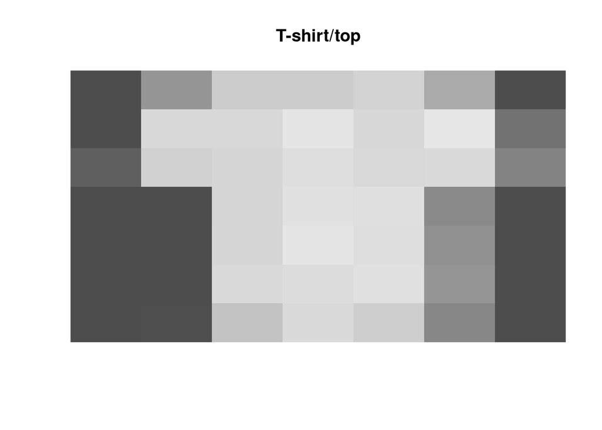

```r
i <- 1
px <- as.numeric(train_raw[i, -1])
mat <- matrix(px, nrow = 7, ncol = 7, byrow = TRUE)
image(t(apply(mat, 2, rev)), col = gray.colors(256),
      main = train_raw$label[i], axes = FALSE)
```

### Model 1 — Multinomial Logistic Regression

This model applies multinomial logistic regression, a linear classifier that models class probabilities using a softmax function. It was selected as a simple, fast baseline with minimal tuning, allowing us to benchmark more complex techniques. The model is trained on each development set and used to predict class labels for the test set; performance is evaluated by misclassification rate and combined scoring. Advantages include interpretability and low computational cost, though accuracy is limited since the method assumes linear decision boundaries. Overall, it provides a stable baseline but is not expected to match nonlinear or ensemble models.

```r
results_model1 <- data.frame()

for(n in n.values){
  for(k in 1:iterations){

    dat_nk <- data.table::copy(dev_sets[[as.character(n)]][[k]])

    dat_nk[, label := as.factor(label)]
    test_local <- data.table::copy(test_raw)
    test_local[, label := factor(label, levels = levels(dat_nk$label))]

    t0 <- Sys.time()
    mod <- multinom(label ~ ., data = dat_nk, trace = FALSE)
    preds <- predict(mod, newdata = test_local, type="class")
    t1 <- Sys.time()

    runtime_sec <- as.numeric(difftime(t1,t0,units="secs"))
    A <- n / N_train_raw
    B <- min(1, runtime_sec / 60)
    C <- mean(preds != test_local$label)
    Points <- 0.15*A + 0.10*B + 0.75*C

    results_model1 <- rbind(
      results_model1,
      data.frame(Model="Model1_multinom", SampleSize=n, Iter=k,
                 A=A, B=B, C=C, Points=Points, runtime=runtime_sec)
    )
  }
}
```

```r
res_m1 <- summarize_results_df(results_model1, "M1_multinom", "best")
res_m1
```

```
         Model Summary SampleSize  Iter       Data          A          B      C
        <char>  <char>      <num> <int>     <char>      <num>      <num>  <num>
1: M1_multinom    best       2000     3 dat_2000_3 0.03333333 0.01306807 0.2528
      Points  time_sec
       <num>     <num>
1: 0.1959068 0.7840841
```

### Model 2 — k-Nearest Neighbors (k=3)

This model uses k-Nearest Neighbors with (k = 3), a simple instance-based method that classifies each test image by the majority label among its three closest training samples in standardized pixel space. We standardized all pixel columns to ensure that distance calculations were not dominated by large-variance features. KNN requires no parameter training, but prediction can be slow on larger datasets because distances are computed at query time. Its advantage is conceptual simplicity and the ability to capture local structure, though it struggles when classes overlap and does not scale well to high dimensional data. Overall, this serves as a lightweight nonlinear baseline.

```r
results_model2 <- data.frame()

for(n in n.values){
  for(k in 1:iterations){

    dat_nk <- data.table::copy(dev_sets[[as.character(n)]][[k]])

    train_raw_x_dt <- dat_nk[, ..pixel_cols]
    test_local     <- data.table::copy(test_raw)
    test_raw_x_dt  <- test_local[, ..pixel_cols]

    train_raw_x <- as.matrix(train_raw_x_dt)
    test_raw_x  <- as.matrix(test_raw_x_dt)

    mu  <- colMeans(train_raw_x)
    sdv <- apply(train_raw_x, 2, sd); sdv[sdv == 0] <- 1

    train_raw_xs <- sweep(sweep(train_raw_x, 2, mu, "-"), 2, sdv, "/")
    test_raw_xs  <- sweep(sweep(test_raw_x,  2, mu, "-"), 2, sdv, "/")

    t0 <- Sys.time()
    preds <- knn2(train_raw=train_raw_xs, test_raw=test_raw_xs, cl=dat_nk$label, k=3)
    t1 <- Sys.time()

    runtime_sec <- as.numeric(difftime(t1,t0,units="secs"))
    A <- n / N_train_raw
    B <- min(1, runtime_sec / 60)
    C <- mean(preds != test_local$label)
    Points <- 0.15*A + 0.10*B + 0.75*C

    results_model2 <- rbind(
      results_model2,
      data.frame(Model="Model2_knn3", SampleSize=n, Iter=k,
                 A=A, B=B, C=C, Points=Points, runtime=runtime_sec)
    )
  }
}
```

```r
res_m2 <- summarize_results_df(results_model2, "M2_knn3", "best")
res_m2
```

```
     Model Summary SampleSize  Iter       Data          A          B      C
    <char>  <char>      <num> <int>     <char>      <num>      <num>  <num>
1: M2_knn3    best       2000     1 dat_2000_1 0.03333333 0.01044037 0.2207
     Points  time_sec
      <num>     <num>
1: 0.171569 0.6264222
```

### Model 3 — Decision Tree (rpart)

This model fits a CART-style decision tree using `rpart` with moderate depth (`maxdepth = 20`) and a small complexity parameter (`cp = 0.001`) to allow reasonably rich structure. Decision trees recursively split the feature space to maximize class purity, producing an interpretable rule-based model. Advantages include transparency and fast inference, but trees can overfit high-dimensional data such as images, even with regularization. Although simple, this provides a useful baseline that can capture nonlinear interactions without requiring feature engineering.

```r
results_model3 <- data.frame()

for(n in n.values){
  for(k in 1:iterations){

    dat_nk <- data.table::copy(dev_sets[[as.character(n)]][[k]])

    dat_nk[, label := as.factor(label)]
    test_local <- data.table::copy(test_raw)
    test_local[, label := factor(label, levels = levels(dat_nk$label))]

    t0 <- Sys.time()
    mod <- rpart(label ~ ., data = dat_nk,
                 method="class",
                 control = rpart.control(cp=0.001, maxdepth=20, minsplit=20))
    preds <- predict(mod, newdata=test_local, type="class")
    t1 <- Sys.time()

    runtime_sec <- as.numeric(difftime(t1,t0,units="secs"))
    A <- n / N_train_raw
    B <- min(1, runtime_sec / 60)
    C <- mean(preds != test_local$label)
    Points <- 0.15*A + 0.10*B + 0.75*C

    results_model3 <- rbind(
      results_model3,
      data.frame(Model="Model3_rpart", SampleSize=n, Iter=k,
                 A=A, B=B, C=C, Points=Points, runtime=runtime_sec)
    )
  }
}
```

```r
res_m3 <- summarize_results_df(results_model3, "M3_rpart", "best")
res_m3
```

```
      Model Summary SampleSize  Iter       Data          A           B      C
     <char>  <char>      <num> <int>     <char>      <num>       <num>  <num>
1: M3_rpart    best       2000     2 dat_2000_2 0.03333333 0.005740118 0.2871
     Points  time_sec
      <num>     <num>
1: 0.220899 0.3444071
```

### Model 4 — Random Forest

This model applies Random Forest, an ensemble of decision trees trained on bootstrap samples with random feature selection at each split. We set `ntree = 120` and `mtry = 7` (≈√49) to balance predictive power and computational cost. Random Forest generally improves stability and accuracy over a single tree by averaging many weak learners, reducing variance and mitigating overfitting. Its main advantages are strong baseline performance and robustness; however, it sacrifices interpretability and can be slower to train than simpler models.

```r
results_model4 <- vector("list", length(n.values) * iterations)
idx <- 0L


rf_ntree <- 120
rf_mtry  <- 7

for (n in n.values) {
  for (k in 1:iterations) {

    dat_nk <- data.table::copy(dev_sets[[as.character(n)]][[k]])

    dat_nk[, label := as.factor(label)]
    test_local <- data.table::copy(test_raw)
    test_local[, label := factor(label, levels = levels(dat_nk$label))]

    t0 <- proc.time()
    rf_model <- randomForest(
      x = dat_nk[, ..px_cols],
      y = dat_nk$label,
      ntree = rf_ntree,
      mtry  = rf_mtry
    )
    rf_pred <- predict(rf_model, newdata = test_local[, ..px_cols])
    time_sec <- (proc.time() - t0)[["elapsed"]]

    A <- n / N_train_raw
    B <- min(1, time_sec / 60)
    C <- mean(rf_pred != test_local$label)
    Points <- 0.15*A + 0.10*B + 0.75*C

    idx <- idx + 1L
    results_model4[[idx]] <- data.table::data.table(
      Model = "Model4_randomForest",
      SampleSize = n, Iter = k,
      ntree = rf_ntree, mtry = rf_mtry,
      A = A, B = B, C = C, Points = Points, runtime = time_sec
    )
  }
}

results_model4 <- data.table::rbindlist(results_model4)
```

```r
res_m4 <- summarize_results_df(results_model4, "M4_randomForest", "best")
res_m4
```

```
             Model Summary SampleSize  Iter       Data          A          B
            <char>  <char>      <num> <int>     <char>      <num>      <num>
1: M4_randomForest    best       2000     2 dat_2000_2 0.03333333 0.01128333
        C    Points time_sec
    <num>     <num>    <num>
1: 0.1933 0.1511033    0.677
```

### Model 5 — Elastic Net

This model uses Elastic Net multinomial regression via **glmnet**, combining L1 and L2 penalties to encourage sparse yet stable solutions. We fix the mixing parameter at `alpha = 0.3`, favoring ridge-style shrinkage while still allowing variable selection. After fitting, predictions are generated on the testing set using the selected λ value. Elastic Net is attractive because it scales well to high-dimensional inputs and reduces overfitting, but the linear decision boundary limits performance relative to more flexible nonlinear models.

```r
results_model5 <- vector("list", length(n.values) * iterations)
idx <- 0L

alpha_val <- 0.3

for (n in n.values) {
  for (k in 1:iterations) {

    dat_nk <- data.table::copy(dev_sets[[as.character(n)]][[k]])

    dat_nk[, label := as.factor(label)]
    test_local <- data.table::copy(test_raw)
    test_local[, label := factor(label, levels = levels(dat_nk$label))]

    x_train <- as.matrix(dat_nk[, ..px_cols])
    y_train <- dat_nk$label
    x_test  <- as.matrix(test_local[, ..px_cols])
    y_test  <- test_local$label

    t0 <- proc.time()
    fit <- glmnet(x = x_train, y = y_train, alpha = alpha_val, family = "multinomial")
    lam <- if (!is.null(fit$lambda.min)) fit$lambda.min else tail(fit$lambda, 1L)
    preds <- predict(fit, newx = x_test, s = lam, type = "class")
    time_sec <- (proc.time() - t0)[["elapsed"]]

    A <- n / N_train_raw
    B <- min(1, time_sec / 60)
    C <- mean(preds != y_test)
    Points <- 0.15*A + 0.10*B + 0.75*C

    idx <- idx + 1L
    results_model5[[idx]] <- data.table::data.table(
      Model = "Model5_elasticNet",
      SampleSize = n, Iter = k,
      alpha = alpha_val,
      A = A, B = B, C = C, Points = Points, runtime = time_sec
    )
  }
}

results_model5 <- data.table::rbindlist(results_model5)
```

```r
res_m5 <- summarize_results_df(results_model5, "M5_elasticNet", "best")
res_m5
```

```
           Model Summary SampleSize  Iter       Data          A          B
          <char>  <char>      <num> <int>     <char>      <num>      <num>
1: M5_elasticNet    best       2000     3 dat_2000_3 0.03333333 0.02661667
        C    Points time_sec
    <num>     <num>    <num>
1: 0.2124 0.1669617    1.597
```

### Model 6 — Neural Network (nnet)

This model is a single-hidden-layer feedforward network trained with softmax output using `nnet`. We use a small architecture (`size = 15`, `decay = 5e-4`, `maxit = 200`) and standardize inputs using training means and standard deviations to aid optimization. Neural nets can learn nonlinear decision boundaries and interactions, offering higher capacity than linear models. The trade-offs are sensitivity to hyperparameters, risk of overfitting, and longer training time than simpler baselines. Here it serves as a compact nonlinear model without the complexity of deep CNNs.

```r
results_model6 <- vector("list", length(n.values) * iterations)
idx <- 0L


nn_size  <- 15
nn_decay <- 5e-4
nn_maxit <- 200

for (n in n.values) {
  for (k in 1:iterations) {

    dat_nk <- data.table::copy(dev_sets[[as.character(n)]][[k]])

    dat_nk[, label := as.factor(label)]
    test_local <- data.table::copy(test_raw)
    test_local[, label := factor(label, levels = levels(dat_nk$label))]

    x_train <- as.matrix(dat_nk[, ..px_cols])
    x_test  <- as.matrix(test_local[, ..px_cols])

    mu  <- colMeans(x_train)
    sdv <- apply(x_train, 2, sd); sdv[sdv == 0] <- 1
    x_train_s <- sweep(sweep(x_train, 2, mu, "-"), 2, sdv, "/")
    x_test_s  <- sweep(sweep(x_test,  2, mu, "-"), 2, sdv, "/")

    y_levels <- levels(dat_nk$label)
    y_mat <- nnet::class.ind(dat_nk$label)

    t0 <- proc.time()
    nn_fit <- nnet::nnet(
      x = x_train_s, y = y_mat,
      size = nn_size, decay = nn_decay, maxit = nn_maxit,
      softmax = TRUE, trace = FALSE
    )
    prob <- predict(nn_fit, newdata = x_test_s, type = "raw")
    pred_idx <- max.col(prob, ties.method = "first")
    preds <- factor(y_levels[pred_idx], levels = y_levels)
    time_sec <- (proc.time() - t0)[["elapsed"]]

    A <- n / N_train_raw
    B <- min(1, time_sec / 60)
    C <- mean(preds != test_local$label)
    Points <- 0.15*A + 0.10*B + 0.75*C

    idx <- idx + 1L
    results_model6[[idx]] <- data.table::data.table(
      Model = "Model6_nnet",
      SampleSize = n, Iter = k,
      size = nn_size, decay = nn_decay, maxit = nn_maxit,
      A = A, B = B, C = C, Points = Points, runtime = time_sec
    )
  }
}

results_model6 <- data.table::rbindlist(results_model6)
```

```r
res_m6 <- summarize_results_df(results_model6, "M6_nnet", "best")
res_m6
```

```
     Model Summary SampleSize  Iter      Data           A           B      C
    <char>  <char>      <num> <int>    <char>       <num>       <num>  <num>
1: M6_nnet    best        500     2 dat_500_2 0.008333333 0.009016667 0.2546
      Points time_sec
       <num>    <num>
1: 0.1931017    0.541
```

### Model 7 — XGBoost

This model applies gradient-boosted decision trees using `xgboost` with a multinomial objective for multi-class prediction. We use modest hyperparameters—learning rate `eta = 0.1`, tree depth `max_depth = 4`, and `80` boosting rounds—to balance accuracy and speed. The method converts factor labels into integer class IDs and predicts class probabilities, then assigns classes via maximum probability. XGBoost handles nonlinear boundaries, feature interactions, and noise well, often outperforming simpler tree models. Its main drawbacks are sensitivity to hyperparameters and higher computational cost compared to single trees or linear models.

```r
results_model7 <- vector("list", length(n.values) * iterations)
idx <- 0L


xgb_eta       <- 0.1
xgb_max_depth <- 4
xgb_subsample <- 0.8
xgb_colsample <- 0.8
xgb_rounds    <- 80

for (n in n.values) {
  for (k in 1:iterations) {


    dat_nk <- data.table::copy(dev_sets[[as.character(n)]][[k]])


    dat_nk[, label := as.factor(label)]
    test_local <- data.table::copy(test_raw)
    test_local[, label := factor(label, levels = levels(dat_nk$label))]


    x_train <- as.matrix(dat_nk[, ..px_cols])
    x_test  <- as.matrix(test_local[, ..px_cols])
    y_levels   <- levels(dat_nk$label)
    num_class  <- length(y_levels)
    y_train_int <- as.integer(dat_nk$label) - 1L

    dtrain <- xgboost::xgb.DMatrix(data = x_train, label = y_train_int)
    dtest  <- xgboost::xgb.DMatrix(data = x_test)


    t0 <- proc.time()
    mod <- xgboost::xgb.train(
      params = list(
        objective        = "multi:softprob",
        num_class        = num_class,
        eta              = xgb_eta,
        max_depth        = xgb_max_depth,
        subsample        = xgb_subsample,
        colsample_bytree = xgb_colsample,
        nthread          = 2
      ),
      data    = dtrain,
      nrounds = xgb_rounds,
      verbose = 0
    )
    prob <- predict(mod, dtest)
    time_sec <- (proc.time() - t0)[["elapsed"]]


    prob_mat <- matrix(prob, nrow = nrow(test_local), ncol = num_class, byrow = TRUE)
    pred_idx <- max.col(prob_mat, ties.method = "first")
    preds <- factor(y_levels[pred_idx], levels = y_levels)


    A <- n / N_train_raw
    B <- min(1, time_sec / 60)
    C <- mean(preds != test_local$label)
    Points <- 0.15*A + 0.10*B + 0.75*C

    idx <- idx + 1L
    results_model7[[idx]] <- data.table::data.table(
      Model = "Model7_xgboost",
      SampleSize = n, Iter = k,
      eta = xgb_eta, max_depth = xgb_max_depth, rounds = xgb_rounds,
      A = A, B = B, C = C, Points = Points, runtime = time_sec
    )
  }
}

results_model7 <- data.table::rbindlist(results_model7)
```

```r
res_m7 <- summarize_results_df(results_model7, "M7_xgboost", "best")
res_m7
```

```
        Model Summary SampleSize  Iter       Data          A      B      C
       <char>  <char>      <num> <int>     <char>      <num>  <num>  <num>
1: M7_xgboost    best       2000     1 dat_2000_1 0.03333333 0.0231 0.1884
    Points time_sec
     <num>    <num>
1: 0.14861    1.386
```

### Model 8 — Gradient Boosting (gbm)

This model uses gradient-boosted trees via `gbm` with a multinomial loss to handle the ten classes. We use modest settings—`n.trees = 500`, `interaction.depth = 3`, `shrinkage = 0.05`, and `bag.fraction = 0.8`—to balance accuracy and runtime. Predictions are produced as class probabilities across trees and converted to labels by taking the maximum probability. GBM captures nonlinearities and interactions better than single trees and often rivals Random Forest and XGBoost on tabular data. Its drawbacks are sensitivity to hyperparameters and longer training times than linear models.

```r
results_model8 <- vector("list", length(n.values) * iterations)
idx <- 0L

gbm_params <- list(
  n.trees = 500,
  interaction.depth = 3,
  shrinkage = 0.05,
  n.minobsinnode = 10,
  bag.fraction = 0.8
)

for (n in n.values) {
  for (k in 1:iterations) {

    dat_nk <- data.table::copy(dev_sets[[as.character(n)]][[k]])

    dat_nk[, label := as.factor(label)]
    test_local <- data.table::copy(test_raw)
    test_local[, label := factor(label, levels = levels(dat_nk$label))]

    lbl_levels  <- levels(dat_nk$label)
    K <- length(lbl_levels)
    y_train_num <- as.integer(dat_nk$label) - 1L

    train_df <- data.frame(y_train_num = y_train_num, dat_nk[, ..px_cols])
    test_df  <- as.data.frame(test_local[, ..px_cols])

    t0 <- proc.time()
    gbm_fit <- gbm::gbm(
      formula = y_train_num ~ .,
      data    = train_df,
      distribution = "multinomial",
      n.trees = gbm_params$n.trees,
      interaction.depth = gbm_params$interaction.depth,
      shrinkage = gbm_params$shrinkage,
      n.minobsinnode = gbm_params$n.minobsinnode,
      bag.fraction = gbm_params$bag.fraction,
      train.fraction = 1.0,
      verbose = FALSE
    )

    pred_prob <- predict(
      gbm_fit,
      newdata = test_df,
      n.trees = gbm_params$n.trees,
      type = "response"
    )

    dims <- dim(pred_prob)
    if (!is.null(dims) && length(dims) == 3) {
      prob_mat <- pred_prob[, , dims[3], drop = TRUE]
    } else if (!is.null(dims) && length(dims) == 2) {
      prob_mat <- pred_prob
    } else {
      prob_mat <- matrix(pred_prob, nrow = nrow(test_local), ncol = K, byrow = FALSE)
    }

    pred_idx <- max.col(prob_mat, ties.method = "first")
    preds <- factor(lbl_levels[pred_idx], levels = lbl_levels)

    time_sec <- (proc.time() - t0)[["elapsed"]]

    A <- n / N_train_raw
    B <- min(1, time_sec / 60)
    C <- mean(preds != test_local$label)
    Points <- 0.15*A + 0.10*B + 0.75*C

    idx <- idx + 1L
    results_model8[[idx]] <- data.table::data.table(
      Model = "Model8_gbm",
      SampleSize = n, Iter = k,
      n.trees = gbm_params$n.trees,
      depth = gbm_params$interaction.depth,
      A = A, B = B, C = C, Points = Points, runtime = time_sec
    )
  }
}

results_model8 <- data.table::rbindlist(results_model8)
```

```r
res_m8 <- summarize_results_df(results_model8, "M8_gbm", "best")
res_m8
```

```
    Model Summary SampleSize  Iter       Data          A         B      C
   <char>  <char>      <num> <int>     <char>      <num>     <num>  <num>
1: M8_gbm    best       2000     1 dat_2000_1 0.03333333 0.1845167 0.1889
      Points time_sec
       <num>    <num>
1: 0.1651267   11.071
```

### Model 9 — Support Vector Machine (RBF)

This model uses an SVM with a radial basis function kernel, which maps inputs into a higher-dimensional space to separate classes with nonlinear decision boundaries. We set `cost = 1` and `gamma = 1/49` (inverse of the feature count) for a simple, stable baseline without heavy tuning. Features are kept in their original scale but `e1071::svm` applies internal scaling, and predictions are made directly on the held-out test set. SVMs are strong at handling complex boundaries and can perform well with limited samples, but they can be slower to train and are sensitive to hyperparameter choices. Interpretability is limited compared to linear models or trees.

```r
results_model9 <- vector("list", length(n.values) * iterations)
idx <- 0L

svm_cost  <- 1
svm_gamma <- 1/49

for (n in n.values) {
  for (k in 1:iterations) {

    dat_nk <- data.table::copy(dev_sets[[as.character(n)]][[k]])

    dat_nk[, label := as.factor(label)]
    test_local <- data.table::copy(test_raw)
    test_local[, label := factor(label, levels = levels(dat_nk$label))]

    x_train_df <- as.data.frame(dat_nk[, ..px_cols])
    x_test_df  <- as.data.frame(test_local[, ..px_cols])
    y_train    <- dat_nk$label
    y_test     <- test_local$label

    t0 <- proc.time()
    svm_mod <- e1071::svm(
      x = x_train_df, y = y_train,
      kernel = "radial",
      cost = svm_cost,
      gamma = svm_gamma,
      scale = TRUE
    )
    pred_m9 <- predict(svm_mod, newdata = x_test_df)
    time_sec <- (proc.time() - t0)[["elapsed"]]

    A <- n / N_train_raw
    B <- min(1, time_sec / 60)
    C <- mean(pred_m9 != y_test)
    Points <- 0.15*A + 0.10*B + 0.75*C

    idx <- idx + 1L
    results_model9[[idx]] <- data.table::data.table(
      Model = "Model9_svm_rbf",
      SampleSize = n, Iter = k,
      cost = svm_cost, gamma = svm_gamma,
      A = A, B = B, C = C, Points = Points, runtime = time_sec
    )
  }
}

results_model9 <- data.table::rbindlist(results_model9)
```

```r
res_m9 <- summarize_results_df(results_model9, "M9_svm_rbf", "best")
res_m9
```

```
        Model Summary SampleSize  Iter       Data          A          B      C
       <char>  <char>      <num> <int>     <char>      <num>      <num>  <num>
1: M9_svm_rbf    best       2000     1 dat_2000_1 0.03333333 0.01523333 0.1992
      Points time_sec
       <num>    <num>
1: 0.1559233    0.914
```

### Model 10 — Naive Bayes

```r
results_model10 <- vector("list", length(n.values) * iterations)
idx <- 0L

for (n in n.values) {
  for (k in 1:iterations) {

    dat_nk <- data.table::copy(dev_sets[[as.character(n)]][[k]])

    dat_nk[, label := as.factor(label)]
    test_local <- data.table::copy(test_raw)
    test_local[, label := factor(label, levels = levels(dat_nk$label))]

    x_train_df <- as.data.frame(dat_nk[, ..px_cols])
    x_test_df  <- as.data.frame(test_local[, ..px_cols])
    y_train    <- dat_nk$label
    y_test     <- test_local$label

    t0 <- proc.time()
    nb_mod <- e1071::naiveBayes(x = x_train_df, y = y_train)
    pred_m10 <- predict(nb_mod, newdata = x_test_df)
    time_sec <- (proc.time() - t0)[["elapsed"]]

    A <- n / N_train_raw
    B <- min(1, time_sec / 60)
    C <- mean(pred_m10 != y_test)
    Points <- 0.15*A + 0.10*B + 0.75*C

    idx <- idx + 1L
    results_model10[[idx]] <- data.table::data.table(
      Model = "Model10_naive_bayes",
      SampleSize = n, Iter = k,
      A = A, B = B, C = C, Points = Points, runtime = time_sec
    )
  }
}

results_model10 <- data.table::rbindlist(results_model10)
```

```r
res_m10 <- summarize_results_df(results_model10, "M10_naive_bayes", "best")
res_m10
```

```
             Model Summary SampleSize  Iter      Data           A      B     C
            <char>  <char>      <num> <int>    <char>       <num>  <num> <num>
1: M10_naive_bayes    best        500     2 dat_500_2 0.008333333 0.0646 0.403
    Points time_sec
     <num>    <num>
1: 0.30996    3.876
```

## Preliminary Results (all 90 fits)

```r
res_names <- ls(pattern = "^results_model\\d+$")
res_tbls  <- if (length(res_names)) mget(res_names, inherits = TRUE) else list()


res_tbls <- Filter(function(x) is.data.frame(x) || data.table::is.data.table(x), res_tbls)

if (!length(res_tbls)) {
  cat("No per-fit results found. Knit the model chunks first.")
} else {

  dt_all <- data.table::rbindlist(lapply(res_tbls, data.table::as.data.table), fill = TRUE)

  if (all(c("SampleSize","Iter") %in% names(dt_all))) {
    dt_all[, Data := sprintf("dat_%d_%d", SampleSize, Iter)]
  } else {
    dt_all[, Data := NA_character_]
  }

  if (!"time_sec" %in% names(dt_all) && "runtime" %in% names(dt_all)) {
    data.table::setnames(dt_all, "runtime", "time_sec")
  }

  data.table::setorder(dt_all, Model, SampleSize, Iter)
  num_cols <- intersect(c("A","B","C","Points"), names(dt_all))
  if (length(num_cols)) {
    dt_all[, (num_cols) := lapply(.SD, function(x) round(x, 4)), .SDcols = num_cols]
  }

  cols_disp <- c("Model","SampleSize","Data","A","B","C","Points")
  cols_disp <- intersect(cols_disp, names(dt_all))

  DT::datatable(
    dt_all[, ..cols_disp],
    rownames = FALSE,
    options = list(pageLength = 30, order = list(list(0, "asc"))),
    caption = "Preliminary Results (all 90 fits: 10 models × 3 sizes × 3 draws)"
  )
}
```

| Model | SampleSize | Data | A | B | C | Points |
| --- | --- | --- | --- | --- | --- | --- |
| Model10_naive_bayes | 500 | dat_500_1 | 0.0083 | 0.0651 | 0.5135 | 0.3929 |
| Model10_naive_bayes | 500 | dat_500_2 | 0.0083 | 0.0646 | 0.403 | 0.31 |
| Model10_naive_bayes | 500 | dat_500_3 | 0.0083 | 0.066 | 0.5284 | 0.4041 |
| Model10_naive_bayes | 1000 | dat_1000_1 | 0.0167 | 0.0643 | 0.4344 | 0.3347 |
| Model10_naive_bayes | 1000 | dat_1000_2 | 0.0167 | 0.0653 | 0.4845 | 0.3724 |
| Model10_naive_bayes | 1000 | dat_1000_3 | 0.0167 | 0.0695 | 0.4786 | 0.3684 |
| Model10_naive_bayes | 2000 | dat_2000_1 | 0.0333 | 0.0666 | 0.4308 | 0.3348 |
| Model10_naive_bayes | 2000 | dat_2000_2 | 0.0333 | 0.0661 | 0.4475 | 0.3472 |
| Model10_naive_bayes | 2000 | dat_2000_3 | 0.0333 | 0.0666 | 0.4499 | 0.3491 |
| Model1_multinom | 500 | dat_500_1 | 0.0083 | 0.0065 | 0.3391 | 0.2562 |

[output cut: 80 more lines]

## Scoreboard (30 rows = averages by Model × Sample Size)

```r
if (!exists("dt_all")) {
  res_names <- ls(pattern = "^results_model\\d+$")
  res_tbls  <- if (length(res_names)) mget(res_names, inherits = TRUE) else list()
  res_tbls  <- Filter(function(x) is.data.frame(x) || data.table::is.data.table(x), res_tbls)
  if (length(res_tbls)) {
    dt_all <- data.table::rbindlist(lapply(res_tbls, data.table::as.data.table), fill = TRUE)
  }
}

if (!exists("dt_all")) {
  cat("No per-fit results found. Knit the model chunks first.")
} else {
  need <- c("Model","SampleSize","A","B","C","Points")
  if (!all(need %in% names(dt_all))) {
    stop("Missing required columns in results to compute scoreboard.")
  }

  sb <- dt_all[, .(
    A = mean(A, na.rm = TRUE),
    B = mean(B, na.rm = TRUE),
    C = mean(C, na.rm = TRUE),
    Points = mean(Points, na.rm = TRUE)
  ), by = .(Model, SampleSize)]

  data.table::setorder(sb, Points)
  sb[, Rank := .I]
  sb[, `:=`(
    A      = round(A, 4),
    B      = round(B, 4),
    C      = round(C, 4),
    Points = round(Points, 4)
  )]

  sb_disp <- sb[, .(Rank, Model, SampleSize, A, B, C, Points)]

  DT::datatable(
    sb_disp,
    rownames = FALSE,
    options = list(pageLength = 30, order = list(list(0, "asc"))),
    caption = "Scoreboard (averages over 3 draws for each Model × Sample Size)"
  )
}
```

| Rank | Model | SampleSize | A | B | C | Points |
| --- | --- | --- | --- | --- | --- | --- |
| 1 | Model7_xgboost | 2000 | 0.0333 | 0.0235 | 0.1907 | 0.1504 |
| 2 | Model4_randomForest | 2000 | 0.0333 | 0.0096 | 0.1964 | 0.1533 |
| 3 | Model9_svm_rbf | 2000 | 0.0333 | 0.0151 | 0.2036 | 0.1592 |
| 4 | Model7_xgboost | 1000 | 0.0167 | 0.0116 | 0.2173 | 0.1667 |
| 5 | Model4_randomForest | 1000 | 0.0167 | 0.0043 | 0.219 | 0.1672 |
| 6 | Model5_elasticNet | 2000 | 0.0333 | 0.0234 | 0.2147 | 0.1684 |
| 7 | Model8_gbm | 2000 | 0.0333 | 0.1842 | 0.1945 | 0.1693 |
| 8 | Model9_svm_rbf | 1000 | 0.0167 | 0.0073 | 0.2249 | 0.1719 |
| 9 | Model8_gbm | 1000 | 0.0167 | 0.0925 | 0.2181 | 0.1753 |
| 10 | Model2_knn3 | 2000 | 0.0333 | 0.0104 | 0.23 | 0.1785 |

[output cut: 20 more lines]

## Discussion

Across the board, error rate dominated overall ranking. Models that both generalized well and executed quickly scored highest. Three techniques—**Random Forest, XGBoost, and SVM (RBF kernel)**—formed a clear top tier across all dataset sizes. They consistently reached the lowest error rates (≈19–21% at the largest sample size), and their relative speed kept them highly ranked once runtime penalties were applied. From a practical engineering perspective, these are the most promising candidates for future refinement, deployment, or integration into production workflows.

Random Forest emerged as the most balanced method: strong accuracy, excellent runtime, and minimal tuning requirements. It is easy to parallelize and tends to degrade gracefully when run with only moderate parameter care. XGBoost reached similar accuracy but required longer training times; it remains a strong choice when more aggressive tuning or hardware acceleration is available. SVM with an RBF kernel delivered similar predictive performance at competitive speed and is comparatively simple to configure, though model sizes can grow rapidly with sample size.

A second tier—**k-Nearest Neighbors, Elastic Net, and a small Neural Network**—performed reasonably but offered strictly worse trade-offs. These models may still be appealing in engineering contexts that prioritize simplicity, well-understood failure modes, or rapid iteration. k-NN is trivial to implement but scales poorly in memory and query cost. Elastic Net is stable and interpretable but accuracy lagged top methods. The small neural network showed no clear advantage over tree-based models in this domain.

Classical approaches—**multinomial logistic regression, decision trees (rpart), and Naive Bayes**—served as lightweight baselines. Their error rates were substantially worse, particularly Naive Bayes, whose simplifying assumptions do not hold for image-like pixel inputs. These methods remain useful for sanity-checks or rapid prototyping but would not be competitive without substantial structural modifications.

GBM warranted special mention: its accuracy was competitive, but training time was 10–20× slower than Random Forest at larger sample sizes. Under the current scoring system, this made it non-viable. If runtime constraints were relaxed—and particularly if GPU resources or aggressive tree depth tuning were available—it could re-enter consideration, but it is clearly dominated under today’s constraints.

Engineers evaluating next steps should consider how production requirements shape algorithm choice. If the main objective is maximum performance at modest computational cost, Random Forest or XGBoost are strong defaults. If integration simplicity, maintainability, or predictable memory footprint is more important, SVM or Elastic Net may be easier to manage. Neural networks may warrant re-evaluation if richer input representations or feature learning become important.

Future work can extend these experiments to larger architectures, model compression strategies, and feature learning methods. However, based on current constraints and results, engineers seeking a first production-quality model should begin with **Random Forest**, then consider **XGBoost or SVM** depending on hardware, latency, and tuning appetite.

## Model Development Responsibilities

For the 10 models, please list the names of the developers along with percentages for how the responsibilities were divided.

1. Ziyao Wang (100%)
2. Ziyao Wang (100%)
3. Ziyao Wang (100%)
4. Yuwen Wang (100%)
5. Yuwen Wang (100%)
6. Yuwen Wang (100%)
7. Yuwen Wang (100%)
8. Clara Dragut (100%)
9. Clara Dragut (100%)
10. Clara Dragut (100%)